# Multivariate Analysis

Author

Helena L. Crowell and Wolfgang Huber

Published

July 13, 2026

# 1 Goal

In this lab you will learn the basics of multivariate analysis and principal component analysis (PCA) using some simple examples.

Work through this lab by running the R code to your computer. Make sure that you understand the inputs and the outputs. You can try out variations and experiment with the code, too. We encourage you to work through this lab with a partner.

# 2 Setup

```r
library("dplyr")
library("ggplot2")
library("GGally")
library("factoextra")
library("ade4")
```

You can either, get data sets from the web,

```r
turtles = read.table(
  url("https://web.stanford.edu/class/bios221/data/PaintedTurtles.txt"),
  header = TRUE
)
download.file(
  url = "https://web.stanford.edu/class/bios221/data/athletes.RData",
  destfile = "athletes.RData",
  mode = "wb"
)
```

or load them from local files on your harddrive.

```r
turtles <- read.table("PaintedTurtles.txt", header = TRUE)
load("athletes.RData")
ls()
```

```
[1] "athletes" "params"   "turtles"
```

```r
head(turtles)
```

```
  sex length width height
1   f     98    81     38
2   f    103    84     38
3   f    103    86     42
4   f    105    86     40
5   f    109    88     44
6   f    123    92     50
```

```r
athletes[1:3, ]
```

```
   m100 long weight highj  m400  m110  disc pole javel m1500
1 11.25 7.43  15.48  2.27 48.90 15.13 49.28  4.7 61.32 268.9
2 10.87 7.45  14.97  1.97 47.71 14.46 44.36  5.1 61.76 273.0
3 11.18 7.44  14.20  1.97 48.29 14.81 43.66  5.2 64.16 263.2
```

Let’s first get to know our data sets.

**NoteQuestions**

1. How many athletes and turtles do you have in the data sets?
2. What is the highest distance in the longjump category? Which athlete (number) made this record?
3. What is the average time across all athletes for the 100m run?
4. Can you plot the histogram showing the distribution of the times for the 100m run?
5. How many athletes of those who run faster than the average in the 100m run, also run faster than the average in the 1500m distance?

Hints for Question 5:

- Calculate the averages of `m100` and `m1500`.
- Compute two logical vectors that say, for each athlete, whether their time is better than the average.
- Count how many athletes meet both conditions

## 2.1 Physics

```r
athletes = mutate(athletes,
    m100 = 100/m100,
    m110 = 110/m110,
    m400 = 400/m400,
    m1500 = 1500/m1500
)
```

# 3 Visual exploration

Now let us look at two-dimensional visualisations: pairs plots. A convenient way to make them is the function `ggpairs` from the `GGally` package. Let us first explore the turtles data.

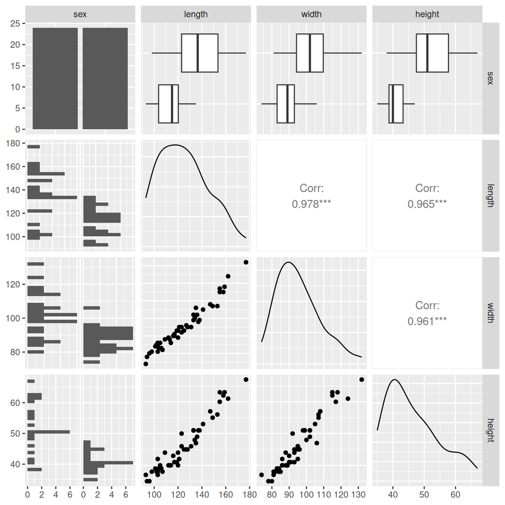

```r
ggpairs(turtles)
```

**NoteQuestion**

What does each of the 16 subpanels show?

**NoteQuestion**

Can you repeat this plot for the `athletes` data?

**NoteQuestion**

In the lecture, we have seen another way to investigate correlations in the data. Use the `Heatmap` function from the `ComplexHeatmap` package to visualise all pairwise correlations of the results from the ten disciplines in the athletes data set.

Hint: use the following code to create your favourite colour scale for the heatmap.

```r
mycolourscale = circlize::colorRamp2(c(-1, 0, 1), c("#FFD700", "#f0f0f0", "#0057B7"))
```

**NoteQuestion**

Similarly, look at the heatmap of the pairwise correlations of the athletes.

Hint: the central idea is to compute the correlation as above, but with the transposed version of the matrix, using the R function `t()`. We also center and scale each discipline’s results with the function `scale()`, to have mean zero and standard deviation one – if we do not do that (try!), all the correlations are close to 1, simply reflecting the fact that the outcomes of different disciplines are measured in different units (meters, seconds), and each discipline has a typical numerical range of outcomes. We will explore scaling more deeply in the next section.

```r
transposed_athletes = t(scale(athletes))
```

# 4 Preprocessing

In many cases, different variables are measured in different units, such that directly comparing the numbers makes no sense. Even if they are in the same unit, they may have different ranges. As discussed in the lecture, we have various options to transform the data. Here, we choose to standardize each variable to a common mean and standard deviation. We do this using the `scale` function, which subtracts the mean and divides by the standard deviation, so that every column has a standard deviation of 1, and a mean of 0.

In the code below, we go through some extra gymnastics to scale only the numeric columns (those not named `sex`) and keep as is the categorical column (the one named `sex`).

```r
scaledTurtles = bind_cols(
  select(turtles, sex),
  scale(select(turtles, !sex))
)
head(scaledTurtles)
```

```
  sex   length   width  height
1   f -1.30300 -1.1390 -0.9929
2   f -1.05888 -0.9023 -0.9929
3   f -1.05888 -0.7445 -0.5163
4   f -0.96123 -0.7445 -0.7546
5   f -0.76593 -0.5867 -0.2780
6   f -0.08239 -0.2712  0.4369
```

**NoteQuestions**

Can you compute the standard deviation and mean of each numerical column in the `turtles` data frame, i.e., before scaling? Do the same on `scaledTurtles`.

We can visualize the pairwise relationship of two columns (for example, height and width) of the scaled data using `ggplot`.

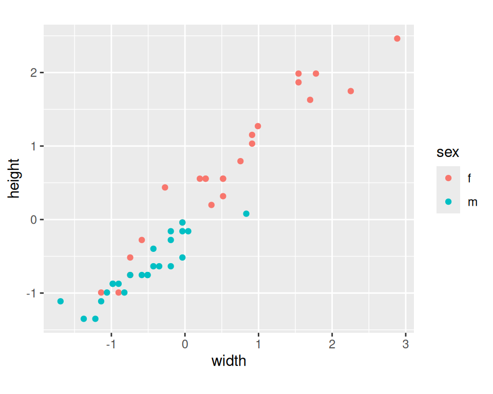

```r
ggplot(scaledTurtles, aes(x = width, y = height, group = sex)) +
  geom_point(aes(color = sex)) + coord_fixed()
```

What is the purpose of the `coord_fixed()` modifier here?

# 5 Dimensionality reduction

## 5.1 By variable selection

In this part, we will use geometrical projections of points in a higher dimensional space and project them down to lower dimensions.

The first example will be the projection of the points in a two-dimensional space (defined by weight and disc distance in the athlete data set) onto a 1-dimensional space.

But first we need to scale the athlete data set. We again use the `scale` function. Calling it is even simpler here, since all the columns are numeric; on the other hand, we need to cast its output, which is of datatype `matrix`, back into a dataframe (`tibble`).

```r
scaledathletes = scale(athletes) |> as_tibble()
scaledathletes
```

```
# A tibble: 33 × 10
      m100    long weight  highj    m400   m110     disc   pole    javel   m1500
     <dbl>   <dbl>  <dbl>  <dbl>   <dbl>  <dbl>    <dbl>  <dbl>    <dbl>   <dbl>
 1 -0.239   0.975   1.13   3.06   0.335  -0.193  1.86    -0.118  0.342    0.495
 2  1.35    1.04    0.746 -0.135  1.50    1.19   0.539    1.08   0.422    0.180
 3  0.0459  1.01    0.168 -0.135  0.924   0.450  0.351    1.38   0.859    0.957
 4  2.46    0.810   0.784  0.503  0.183   0.636  0.658    0.480  0.837   -0.703
 5  0.712   0.975  -0.793 -0.135  1.77    1.32  -0.310    1.38  -0.360    1.51
 6  1.53    1.93   -0.298  1.46   0.875   1.80   0.190    0.480 -1.32     0.1000
 7  0.0459 -0.274   0.108  0.822 -0.0804  1.34  -0.181    2.87   0.393   -1.12
 8  0.585  -0.602   1.02   0.184  1.00    1.40  -0.278    0.181  0.648    0.740
 9  0.169  -0.0438  0.408  0.503  0.0981  0.761  0.00163  0.480  1.28     0.442
10 -0.158   0.482   0.956 -0.135  0.623   0.553  1.52     1.38   0.00750 -1.19
# ℹ 23 more rows
```

We start with p being a 2-dimensional plot of disc vs weight. We add a mock data column `zero` to use as coordinates for some of the subsequent plotting.

```r
p = ggplot(mutate(scaledathletes, zero = 0),
           aes(x = weight, y = disc)) + geom_point(shape = 1) + coord_fixed()
```

Then we add the projected points and the dashed lines.

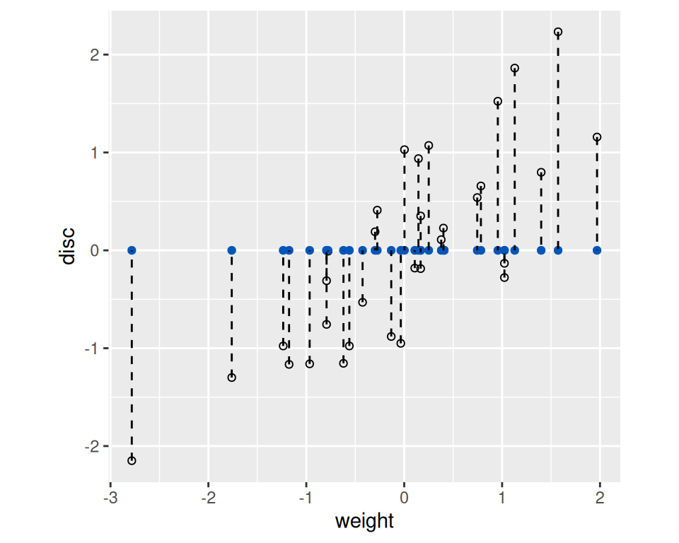

```r
p + geom_point(aes(y = zero), color = "#0056B9") +
    geom_segment(aes(xend = weight, yend = zero), linetype = "dashed")
```

The blue points show the projection of the data onto a single variable, `weight`, in the $x$-axis. We can make a similar plot showing the projection onto the $y$-axis.

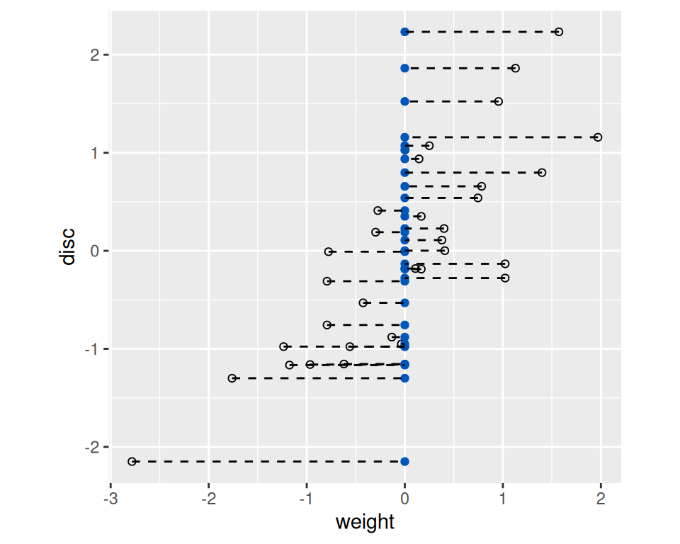

```r
p + geom_point(aes(x = zero), color = "#0056B9") +
    geom_segment(aes(yend = disc, xend = zero), linetype = "dashed")
```

## 5.2 By fitting a line

In the above example when projecting the 2-dimensional points to the `weight` axis, we lost the `disc` information; and vice versa. To keep more information, we will now project the 2 dimensional point cloud onto another line.

```r
reg1 = lm(disc ~ weight, data = scaledathletes)
```

### 5.2.1 Linear regression

```r
a1 = reg1$coefficients[1] # Intercept
b1 = reg1$coefficients[2] # slope
```

Plot the points `p` (computed above) and the regression line.

```r
pline = p + geom_abline(intercept = a1, slope = b1, col = "#0056B9", lwd = 1.5) + coord_fixed()
```

Add the projection lines (from the point to its fitted value)

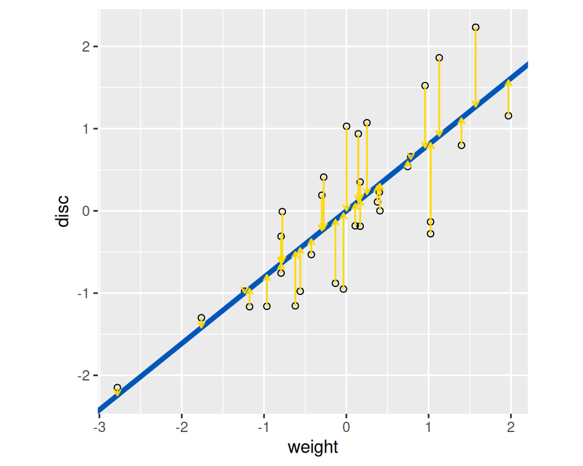

```r
pline + geom_segment(aes(xend = weight, yend = reg1$fitted),
                     color = "#FFD800", arrow = arrow(length = unit(0.15, "cm")))
```

Instead, we can also regress `weight` on `discs` and generate a similar plot.

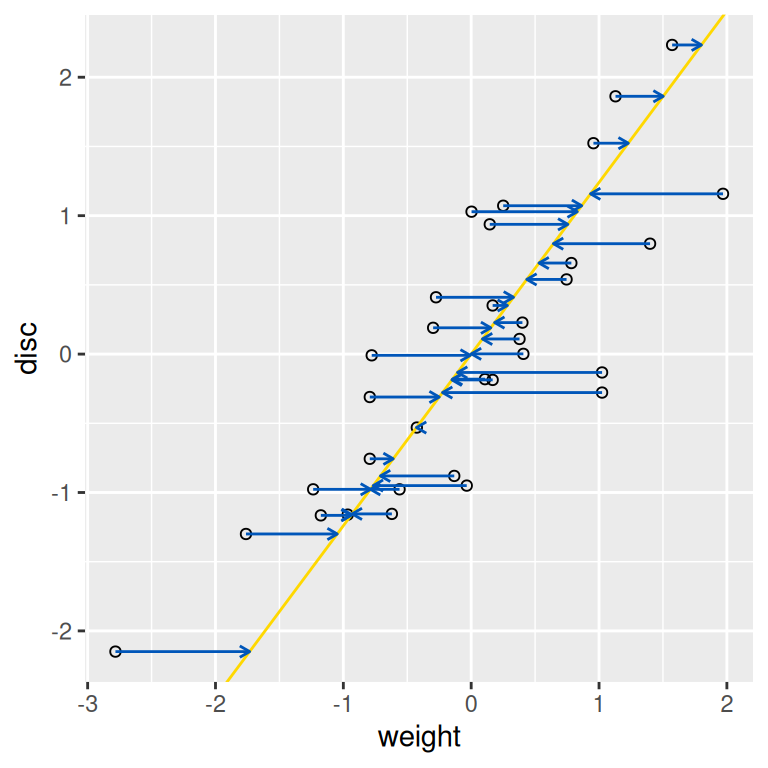

```r
reg2 = lm(weight ~ disc, data = scaledathletes)
a2 = reg2$coefficients[1]
b2 = reg2$coefficients[2]

ggplot(mutate(scaledathletes, zero = 0),
  aes(y = weight, x = disc)) + geom_point(shape = 1) +
  coord_fixed() +
  geom_abline(intercept = a2, slope = b2, col = "#FFD800") +
  geom_segment(
    aes(y = weight, x = disc, yend = reg2$fitted, xend = disc),
    colour = "#0056B9",
    arrow = arrow(length = unit(0.15, "cm"))
    ) +
  coord_flip()
```

Now let us make a plot that shows all points, as well as both regression lines, i.e., from `lm(disc ~ weight)` as well as `lm(weight ~ disc)`.

We plot the data such that the $x$-axis is `disc` and the $y$-axis is `weight`. So we can directly use the intercept and slope parameters from the first regression, `reg1`. For the second regression, `reg2`, we invert
$$\begin{align}
y&=a+bx\quad\quad\Leftrightarrow\\
x&=-\frac{a}{b}+\frac{1}{b}y
\end{align}$$

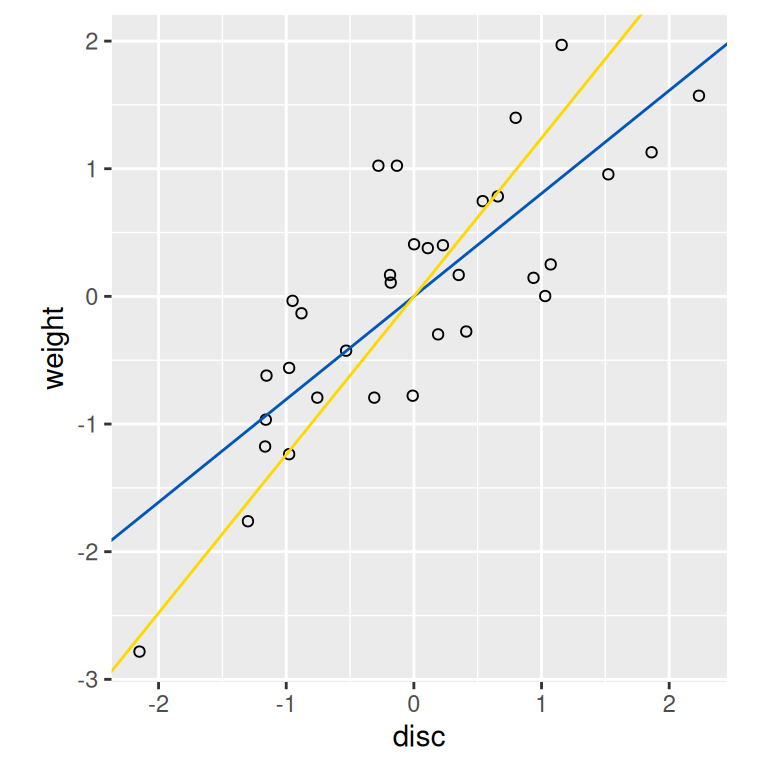

```r
ggplot(scaledathletes, aes(x = disc, y = weight)) + geom_point(shape = 1) +
  coord_fixed() +
  geom_abline(intercept =     a1, slope =   b1, col = "#0056B9") +
  geom_abline(intercept = -a2/b2, slope = 1/b2, col = "#FFD800")
```

### 5.2.2 A line that minimizes distances in both directions

Below we are plotting a line chosen to minimize the error in both the horizontal and vertical directions. This results in minimizing the diagonal projections onto the line.

Specifically, we compute a line that minimizes the sum of squares of the orthogonal (perpendicular) projections of data points onto it. We call this the principal component line.

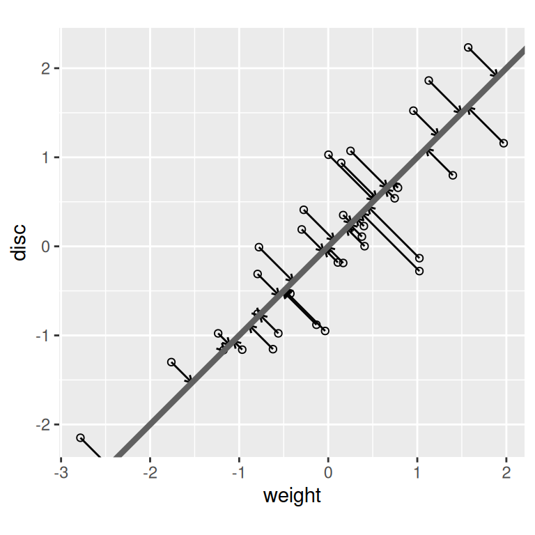

```r
X = as.matrix(select(scaledathletes, disc, weight))
svda = svd(X)
pc = X %*% svda$v[, 1] %*% t(svda$v[, 1])
bp = svda$v[2, 1] / svda$v[1, 1]
ap = mean(pc[, 2]) - bp * mean(pc[, 1])

p + geom_segment(xend = pc[, 1], yend = pc[, 2], arrow = arrow(length = unit(0.15, "cm"))) +
  geom_abline(intercept = ap, slope = bp, col = "#606060", lwd = 1.5) +
  coord_fixed()
```

Now let us see how we can use what we learned on a higher-dimensional data set.

# 6 Turtles PCA

We already saw above that the variables length, width and height are strongly correlated. Let’s do the PCA. We use `prcomp` built-in centering and scaling, so provide the original (unscaled) `turtles` dataframe.

```r
pca_turtles = prcomp(select(turtles, !sex), center = TRUE, scale. = TRUE)
pca_turtles
```

```
Standard deviations (1, .., p=3):
[1] 1.7134 0.2070 0.1464

Rotation (n x k) = (3 x 3):
          PC1     PC2      PC3
length 0.5788  0.3250  0.74790
width  0.5780  0.4835 -0.65741
height 0.5753 -0.8128 -0.09197
```

To look at the relative importance of the principal components,we can look at their variances: the screeplot. The screeplot shows the eigenvalues for the standardized data.

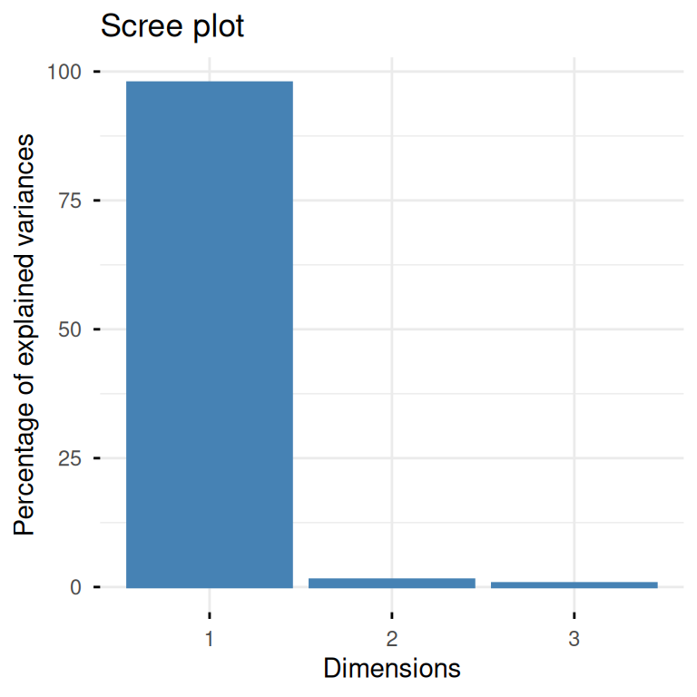

```r
fviz_eig(pca_turtles, geom = "bar", width = 0.4)
```

We see one very large component and two much smaller ones. In this case the data are (almost) one dimensional. We can interpret as the underlying (“latent”) variable `size`, which affects length, width and height each in more or less the same, approximately proportional way.

**NoteQuestion**

What is the percentage of variance explained by the first PC? How can you obtain this value from the pca_turtles object?

Now, let us plot the individual animals, represented by their PC1 and PC2 coordinates. We can in addition show how the original variables align with the PCs. This called a biplot.

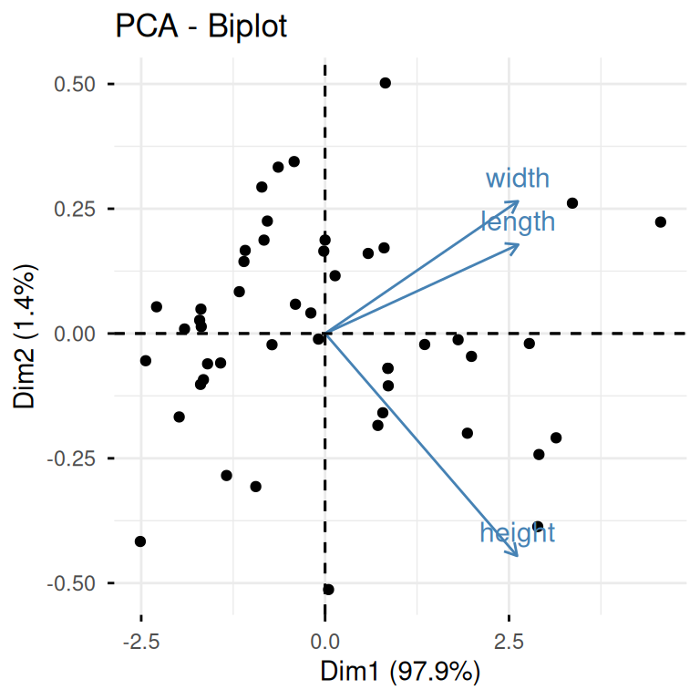

```r
fviz_pca_biplot(pca_turtles, label = "var")
```

**NoteQuestions**

1. Can you extend this plotting code to color the female samples differently than the male samples?
2. Do the male or female turtles tend to be larger?

We see that the females are larger.

# 7 Athletes PCA

```r
pca_athletes = prcomp(athletes, center = TRUE, scale. = TRUE)
```

Just like above for the turtles data set, let us look at scree plot and biplot.

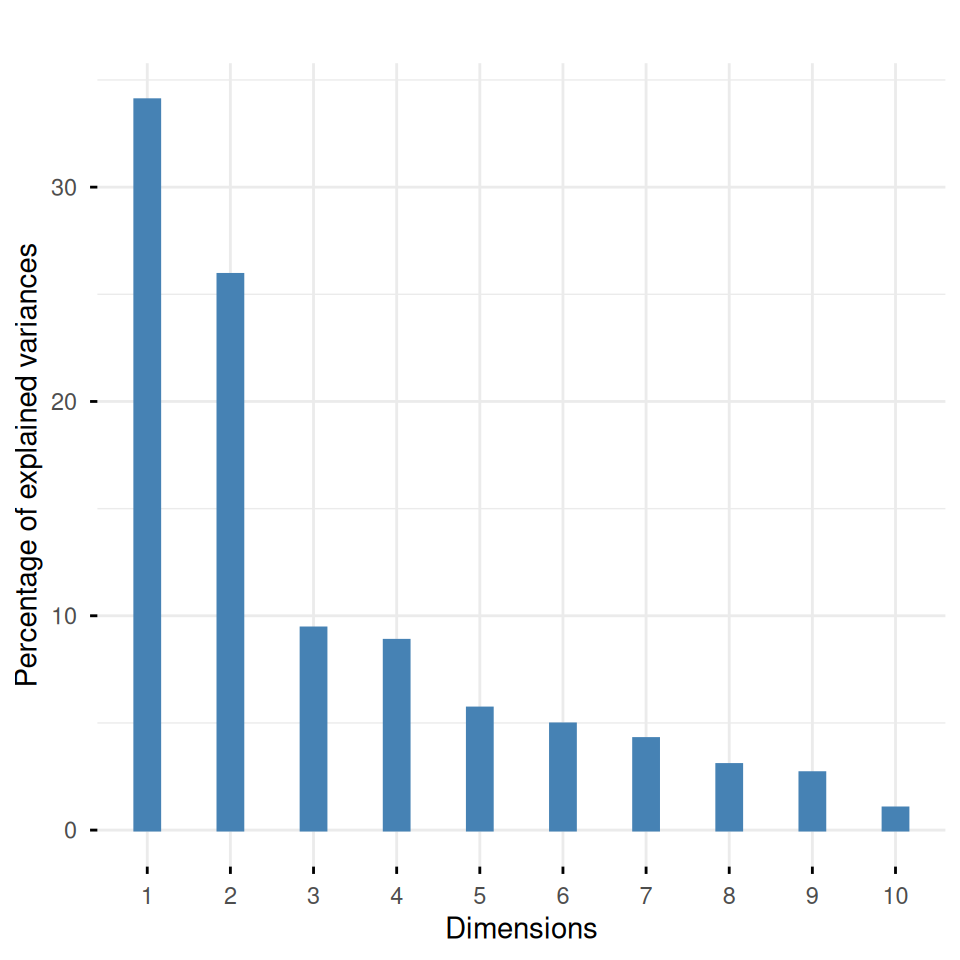

```r
fviz_eig(pca_athletes, geom = "bar", bar_width = 0.3) + ggtitle("")
```

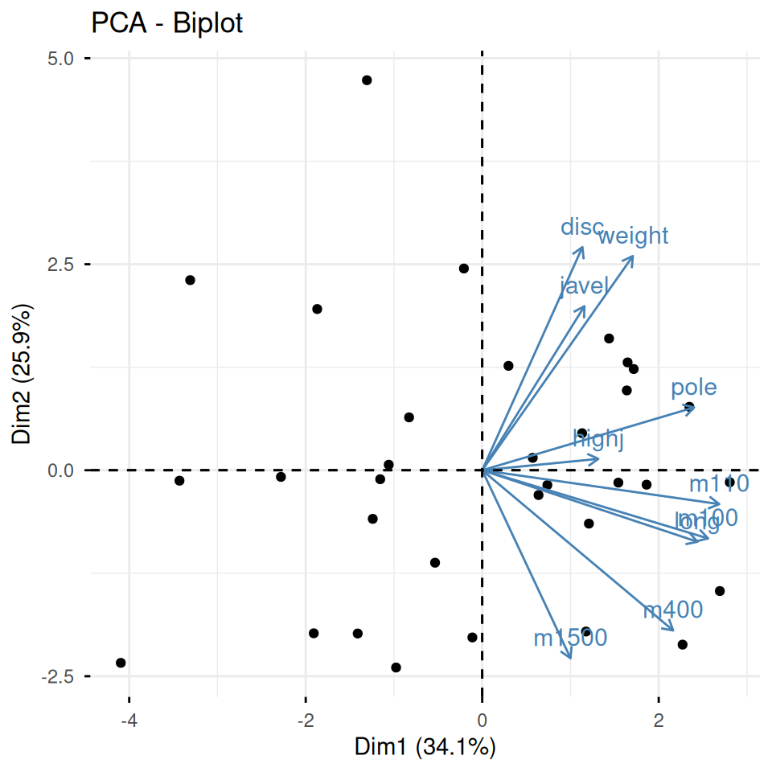

```r
fviz_pca_biplot(pca_athletes, label = "var")
```

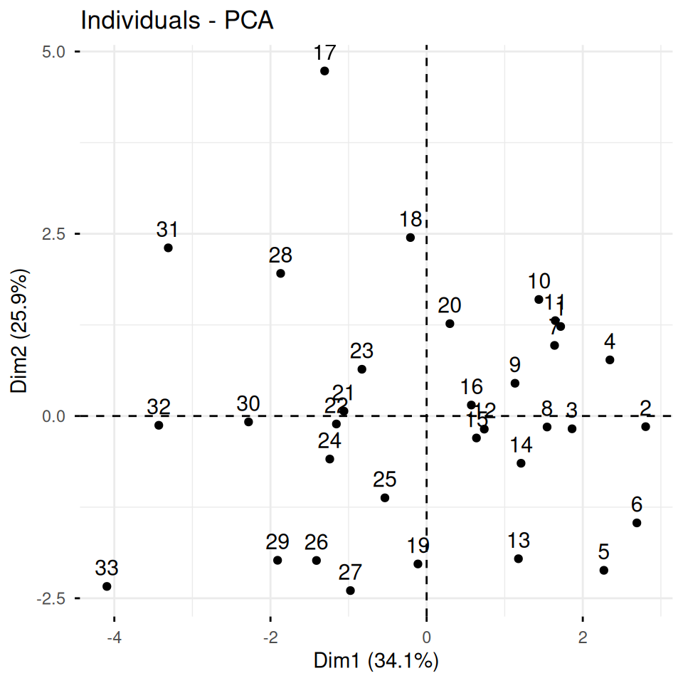

```r
fviz_pca_ind(pca_athletes)
```

**NoteQuestion**

What do you notice in the last plot above, which shows the row numbers of the individuals in the `athletes` dataframe?